# PPCA0026 - Demo: Visualização Interativa com R

Demonstração para Semana 2, Parte 2

Author

Prof. Donald M. Pianto

Published

June 6, 2025

## Objetivo e Configuração

Este documento demonstra como criar visualizações interativas em R, aplicando os conceitos discutidos na aula. Vamos cobrir:

1. **Interatividade Básica com `plotly`**: Como transformar um gráfico estático `ggplot2` em um interativo, demonstrando os conceitos de **Details-on-Demand** (Tooltips) e **Zoom/Pan**.
2. **Interatividade Coordenada com `crosstalk`**: Como criar filtros dinâmicos e visualizações conectadas (**Linking & Brushing**).

**Referências de Conceitos:**

- `InteractionVis.pdf` (especialmente p. 3, 6-9, 37, 50, 54)
- *Interactive web-based data visualization with R, plotly, and shiny* (Carson Sievert)

### 1. Configuração Inicial: Carregando Pacotes

Primeiro, vamos carregar os pacotes necessários. Se você não os tiver instalados, execute `install.packages("tidyverse", "plotly", "crosstalk", "DT")` no seu console.

```r
# Carrega o tidyverse para manipulação de dados (dplyr) e gráficos estáticos (ggplot2)
library(tidyverse)

# Carrega o plotly para tornar os gráficos interativos
library(plotly)

# Carrega o crosstalk para conectar widgets e gráficos
library(crosstalk)

# Carrega o DT para criar tabelas de dados interativas
library(DT)
```

## 2. Interatividade Básica: `ggplotly()`

A maneira mais rápida de adicionar interatividade é usando a função `ggplotly()` do pacote `plotly`. Ela transforma um objeto `ggplot` estático em um gráfico web interativo.

Isto demonstra diretamente os seguintes conceitos:

- **Details-on-Demand**: Passe o mouse sobre um ponto para ver seus valores. (Ref: `InteractionVis-50.pdf`)
- **Zoom e Pan**: Clique e arraste para ampliar uma região. Dê um duplo clique para redefinir a visualização. (Ref: `InteractionVis-37.pdf`, `InteractionVis-50.pdf`)

### 2.1. Criando um Gráfico `ggplot2` Estático

Vamos começar com um gráfico de dispersão simples usando o dataset `mpg`.

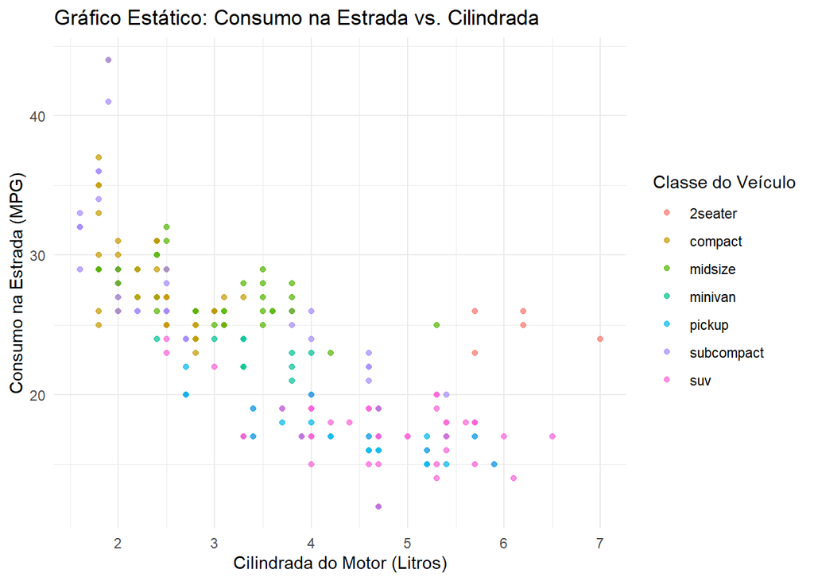

```r
# Criando o objeto ggplot estático
p_static <- ggplot(mpg, aes(x = displ, y = hwy, color = class)) +
  geom_point(alpha = 0.7) +
  labs(
    title = "Gráfico Estático: Consumo na Estrada vs. Cilindrada",
    x = "Cilindrada do Motor (Litros)",
    y = "Consumo na Estrada (MPG)",
    color = "Classe do Veículo"
  ) +
  theme_minimal()

# Exibindo o gráfico estático
p_static
```

### 2.2. Transformando o Gráfico em Interativo

Agora, aplicamos `ggplotly()` ao nosso objeto de gráfico estático.

```r
# Transformando o objeto ggplot em um objeto plotly
# A saída será um gráfico HTML interativo
ggplotly(p_static)
```

[interactive chart not shown]

**Atividade em Aula:**

1. Passe o mouse (`hover`) sobre os pontos de dados. O que você observa? (Details-on-Demand)
2. Clique e arraste com o mouse para criar um retângulo sobre uma área densa de pontos. O que acontece? (Zoom)
3. Dê um duplo clique em qualquer lugar no gráfico. Qual o resultado? (Reset Zoom)
4. Clique nos itens da legenda para ocultar/mostrar classes de veículos.

## 3. Interatividade Coordenada: `crosstalk`

O pacote `crosstalk` permite que múltiplos widgets (gráficos, tabelas, filtros) “conversem” entre si, criando uma experiência de exploração de dados mais rica.

### 3.1. Filtros Dinâmicos

Isto demonstra o conceito de **Filtros** e **Dynamic Queries** (Ref: `InteractionVis-9.pdf`, `InteractionVis-54.pdf`). Os widgets de filtro permitem que o usuário condicionalmente exiba subconjuntos dos dados.

#### Passo 1: Criar um Objeto de Dados Compartilhado (`SharedData`)

Para que os widgets se comuniquem, eles precisam operar sobre um mesmo conjunto de dados compartilhado.

```r
# Criando um objeto SharedData a partir do dataset mpg
# CORREÇÃO: A chave (key) deve ser um identificador único para cada linha.
# Usar `row.names()` é uma forma segura de garantir isso.
shared_mpg <- SharedData$new(mpg, key = ~row.names(mpg))
```

#### Passo 2: Criar Widgets de Filtro e um Gráfico Conectado

Vamos criar filtros para uma variável contínua (`hwy`) e uma categórica (`class`), e conectá-los a um gráfico de dispersão.

```r
# Os widgets e o gráfico precisam ser combinados.
# A função bscols() (bootstrap columns) ajuda a organizar os elementos lado a lado.
bscols(
  # Coluna dos widgets de filtro
  widths = c(3, NA), # Define a largura da coluna do filtro (3 de 12)
  list(
    filter_slider("hwy_filter", "Consumo na Estrada (hwy)", shared_mpg, ~hwy, step = 1),
    filter_checkbox("class_filter", "Classe do Veículo", shared_mpg, ~class, inline = FALSE)
  ),
  # Coluna do gráfico
  ggplotly(
    ggplot(shared_mpg, aes(x = cty, y = hwy)) +
      geom_point(aes(color = drv), alpha = 0.5) +
      labs(title = "Consumo Cidade vs. Estrada", x = "Consumo (Cidade)", y = "Consumo (Estrada)")
  )
)
```

Consumo na Estrada (hwy)

Classe do Veículo

2seater

compact

midsize

minivan

pickup

subcompact

suv

[interactive chart not shown]

**Atividade em Aula:**

1. Mova o controle deslizante (`slider`) de “Consumo na Estrada”. O que acontece com o gráfico?
2. Marque/desmarque as caixas de seleção (`checkbox`) de “Classe do Veículo”. Como o gráfico responde?

### 3.2. Visualizações Conectadas (Linking & Brushing)

Este é um dos conceitos mais importantes da exploração visual interativa. Ao selecionar (“brushing”) dados em uma visualização, os dados correspondentes são destacados (“linking”) em outras visualizações. (Ref: `InteractionVis-6.pdf` a `InteractionVis-8.pdf`).

Vamos conectar dois gráficos de dispersão e uma tabela de dados.

```r
# Usaremos o mesmo objeto 'shared_mpg' criado anteriormente.

# Criando os componentes: dois gráficos e uma tabela
plot1 <- ggplot(shared_mpg, aes(x = displ, y = hwy, color = drv)) +
  geom_point(alpha = 0.5) +
  labs(title = "Dispersão 1: hwy vs displ")

plot2 <- ggplot(shared_mpg, aes(x = cty, y = hwy, color = drv)) +
  geom_point(alpha = 0.5) +
  labs(title = "Dispersão 2: hwy vs cty")

tabela_dados <- datatable(shared_mpg, extensions = 'Buttons', options = list(
  dom = 'Bfrtip',
  buttons = c('copy', 'csv', 'excel', 'pdf', 'print'),
  pageLength = 5 # Mostrar apenas 5 linhas por vez
))

# Organizando os componentes
# A função highlight() do plotly é a chave para ativar o brushing
bscols(
  widths = c(6, 6), # Duas colunas de igual largura
  # CORREÇÃO: Removido `persistent = TRUE` para seguir as boas práticas.
  # A seleção persistente agora é feita pelo usuário segurando a tecla 'Shift'.
  # Este é um bom ponto para ensinar aos alunos sobre esta funcionalidade.
  highlight(ggplotly(plot1, tooltip = "class"), "plotly_selected"),
  highlight(ggplotly(plot2, tooltip = "class"), "plotly_selected")
)
```

```
Setting the `off` event (i.e., 'plotly_deselect') to match the `on` event (i.e., 'plotly_selected'). You can change this default via the `highlight()` function.
Setting the `off` event (i.e., 'plotly_deselect') to match the `on` event (i.e., 'plotly_selected'). You can change this default via the `highlight()` function.
```

[interactive chart not shown]

```r
# A tabela aparecerá abaixo dos gráficos
highlight(tabela_dados, "plotly_selected")
```

|  | manufacturer | model | displ | year | cyl | trans | drv | cty | hwy | fl | class |
| --- | --- | --- | --- | --- | --- | --- | --- | --- | --- | --- | --- |
| 1 | audi | a4 | 1.8 | 1999 | 4 | auto(l5) | f | 18 | 29 | p | compact |
| 2 | audi | a4 | 1.8 | 1999 | 4 | manual(m5) | f | 21 | 29 | p | compact |
| 3 | audi | a4 | 2 | 2008 | 4 | manual(m6) | f | 20 | 31 | p | compact |
| 4 | audi | a4 | 2 | 2008 | 4 | auto(av) | f | 21 | 30 | p | compact |
| 5 | audi | a4 | 2.8 | 1999 | 6 | auto(l5) | f | 16 | 26 | p | compact |
| 6 | audi | a4 | 2.8 | 1999 | 6 | manual(m5) | f | 18 | 26 | p | compact |
| 7 | audi | a4 | 3.1 | 2008 | 6 | auto(av) | f | 18 | 27 | p | compact |
| 8 | audi | a4 quattro | 1.8 | 1999 | 4 | manual(m5) | 4 | 18 | 26 | p | compact |
| 9 | audi | a4 quattro | 1.8 | 1999 | 4 | auto(l5) | 4 | 16 | 25 | p | compact |
| 10 | audi | a4 quattro | 2 | 2008 | 4 | manual(m6) | 4 | 20 | 28 | p | compact |

[output cut: 224 more lines]

**Atividade em Aula:**

1. No “Dispersão 1”, use a ferramenta “Lasso Select” ou “Box Select” (na barra de ferramentas do Plotly) para selecionar um grupo de pontos.
2. Observe o que acontece simultaneamente no “Dispersão 2” e na tabela de dados abaixo. A seleção é sincronizada.
3. Tente novamente, mas desta vez segure a tecla **Shift** enquanto faz a seleção. Note que a seleção agora “persiste” (permanece) mesmo depois de soltar o mouse.

## Conclusão

Nesta demonstração, vimos como usar os pacotes `plotly` e `crosstalk` em R para implementar conceitos fundamentais de visualização interativa.

- `ggplotly` é a porta de entrada para interatividade, adicionando **Details-on-Demand** e **Zoom/Pan**.
- `crosstalk` permite criar dashboards de exploração mais complexos com **Filtros Dinâmicos** e **Visualizações Conectadas (Linking & Brushing)**, sem a necessidade de um servidor `shiny`.

Estas ferramentas são extremamente úteis para a fase de Análise Exploratória de Dados (EDA) em qualquer projeto de mineração de dados.